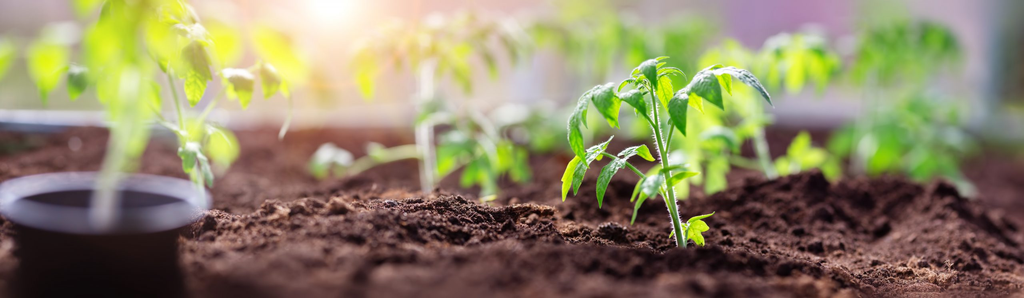

# Plant Seedlings Classification

# **General Overview**

## Background & Context

In recent times, the field of agriculture has been in urgent need of modernizing, since the amount of manual work people need to put in to check if plants are growing correctly is still highly extensive. Despite several advances in agricultural technology, people working in the agricultural industry still need to have the ability to sort and recognize different plants and weeds, which takes a lot of time and effort in the long term. The potential is ripe for this trillion-dollar industry to be greatly impacted by technological innovations that cut down on the requirement for manual labor, and this is where Artificial Intelligence can actually benefit the workers in this field, as **the time and energy required to identify plant seedlings will be greatly shortened by the use of AI and Deep Learning.** The ability to do so far more efficiently and even more effectively than experienced manual labor, could lead to better crop yields, the freeing up of human inolvement for higher-order agricultural decision making, and in the long term will result in more sustainable environmental practices in agriculture as well.

## Objective

The aim of this project is to Build a Convolutional Neural Netowrk to classify plant seedlings into their respective categories.

- The goal of the project is to create a classifier capable of determining a plant's species from an image.

## Data Dictionary

The Aarhus University Signal Processing group, in collaboration with the University of Southern Denmark, has recently released a dataset containing **images of unique plants belonging to 12 different species.**

- The data file names are:
  - images.npy
  - Label.csv
- Due to the large volume of data, the images were converted to the images.npy file and the labels are also put into Labels.csv, so that you can work on the data/project seamlessly without having to worry about the high data volume.

**List of Species**

- Black-grass
- Charlock
- Cleavers
- Common Chickweed
- Common Wheat
- Fat Hen
- Loose Silky-bent
- Maize
- Scentless Mayweed
- Shepherds Purse
- Small-flowered Cranesbill
- Sugar beet

# **Sanity Checks**

## Importing Libraries

```python
# Import necessary Libraries

import numpy as np
import pandas as pd
import matplotlib.pyplot as plt
import seaborn as sns
from wordcloud import WordCloud
import random
import math

# sklearn modules
from sklearn import preprocessing
from sklearn.preprocessing import LabelBinarizer
from sklearn.metrics import classification_report
from sklearn.model_selection import train_test_split
from sklearn.metrics import confusion_matrix
from sklearn.utils import class_weight

# Tensorflow & Keras modules
import tensorflow as tf
from tensorflow.keras.preprocessing.image import ImageDataGenerator
from tensorflow.keras.models import Sequential
from tensorflow.keras.layers import (
    Dense,
    Dropout,
    Flatten,
    Conv2D,
    MaxPooling2D,
    MaxPool2D,
    BatchNormalization,
    Activation
)
from tensorflow.keras.optimizers import Adam,SGD
from tensorflow.keras import backend
from keras.callbacks import ReduceLROnPlateau


# Image display & manipulation modules
import cv2
from google.colab.patches import cv2_imshow

# Import VGG19
from tensorflow.keras.applications import VGG19

# Ignore warnings
import warnings
warnings.filterwarnings('ignore')
```

*Observation*

- The essential libraries are loaded.

## Mounting Drive

```python
# Mount drive
from google.colab import drive
drive.mount('/content/drive')
```

## Loading the Datasets

```python
# Load Data from drive
images_path = '/content/drive/MyDrive/Colab Notebooks/Computer Vision/images.npy'
labels_path = '/content/drive/MyDrive/Colab Notebooks/Computer Vision/Labels.csv'

images = np.load(images_path)
labels = pd.read_csv(labels_path)
```

*Observation*

- Datasets loaded successfully.

## Data Overview

### Understand the shape of the dataset

```python
# Print the shape of both images and labels
print(images.shape)
print(labels.shape)
```

```
(4750, 128, 128, 3)
(4750, 1)
```

*Observation*

- There are 4,750 images each having a dimension of 128x128 and 3 channels (RGB).
- There are 4,750 labels.

# **Exploratory Data Analysis**

## Checking The Names, Counts & Percentages

```python
# Display the Class List and the Number of Classes

num_classes = labels.nunique().sum()            # Number of Classe
class_list=np.unique(labels)                    # Class List

print("The Number of Classes Present is: \n")
print(num_classes)
print("\n")
print("Here are the Names of the Seedlings: \n")
print(class_list)
```

```
The Number of Classes Present is:

12


Here are the Names of the Seedlings:

['Black-grass' 'Charlock' 'Cleavers' 'Common Chickweed' 'Common wheat'
 'Fat Hen' 'Loose Silky-bent' 'Maize' 'Scentless Mayweed'
 'Shepherds Purse' 'Small-flowered Cranesbill' 'Sugar beet']
```

*Observation*

- There are 12 Classes and the names of the seedlings are unique

```python
# Display the count and percentages of each seedling

# Storing the value counts of target variable
value_counts = labels['Label'].value_counts()

# Create a new DataFrame with a column name
seedlings_counts = pd.DataFrame({'Count': value_counts})

# Create a new column for percentages
percentage_distribution = np.round(((labels['Label'].value_counts(normalize=True)).values * 100), 2)
seedlings_counts['Percentage'] = percentage_distribution

seedlings_counts
```

|  | Count | Percentage |
| --- | --- | --- |
| Loose Silky-bent | 654 | 13.77 |
| Common Chickweed | 611 | 12.86 |
| Scentless Mayweed | 516 | 10.86 |
| Small-flowered Cranesbill | 496 | 10.44 |
| Fat Hen | 475 | 10.00 |
| Charlock | 390 | 8.21 |
| Sugar beet | 385 | 8.11 |
| Cleavers | 287 | 6.04 |
| Black-grass | 263 | 5.54 |
| Shepherds Purse | 231 | 4.86 |
| Common wheat | 221 | 4.65 |
| Maize | 221 | 4.65 |

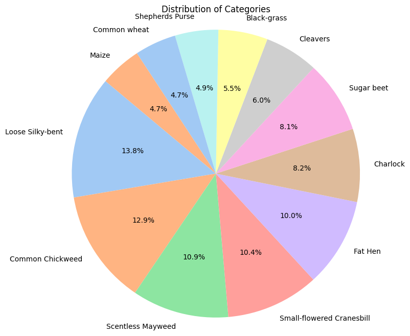

```python
# Create a pie chart using seaborn
plt.figure(figsize=(8, 8))
sns.set_palette("pastel")
plt.pie(value_counts, labels=value_counts.index, autopct='%1.1f%%', startangle=140)
plt.title('Distribution of Categories')
plt.axis('equal')  # Equal aspect ratio ensures the pie chart appears as a circle.
plt.show()
```

*Observation*

- The Dataset is imbalanced
- `Loose Silky-bent` alone represent 13.77% of the dataset (654) with `Common wheat` and `Maize` being the least represented class with 4.65% (221).

## Checking The Distribution of The Target Variable (labels)

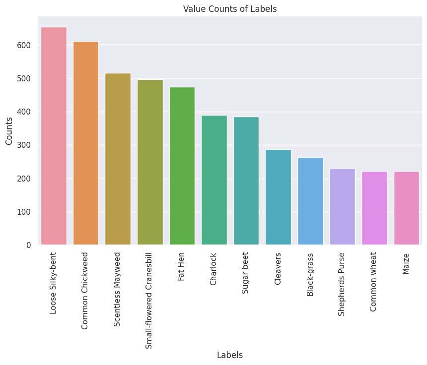

```python
# Calculate the value counts (the categories are in descending order by default)
ordered_labels = value_counts.index.tolist()

# Set the figure size using sns.set()
sns.set(rc={'figure.figsize':(10,6)})  # Adjust the width (10) and height (6) as per your preference

# Plotting the value counts of the 'Label' column in descending order
sns.countplot(x='Label', data=labels, order=ordered_labels)

# Rotating the x-axis labels for better readability
plt.xticks(rotation=90)

# Adding labels and title to the plot
plt.xlabel('Labels')
plt.ylabel('Counts')
plt.title('Value Counts of Labels')

# Show the plot
plt.show()
```

*Observation*

### Word Cloud Representation of the Dataset

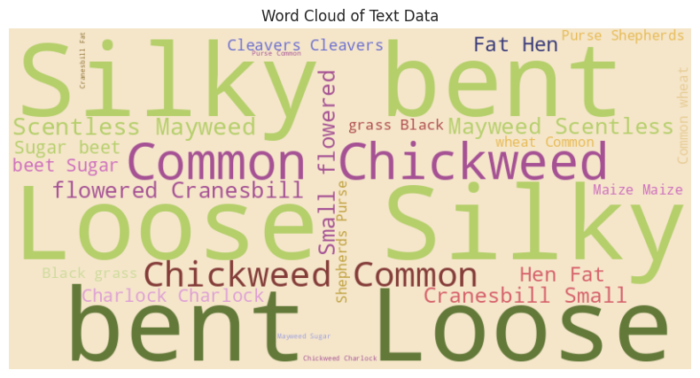

```python
# Generate the Test Data
text_data = ' '.join(labels["Label"])

# Create a word cloud
background_color = '#F5E6CA'
wordcloud = WordCloud(width=800, height=400, background_color=background_color, colormap='tab20b').generate(text_data)

# Display the generated word cloud using matplotlib
plt.figure(figsize=(10, 5))
plt.imshow(wordcloud, interpolation='bilinear')
plt.axis('off')
plt.title('Word Cloud of Text Data')
plt.show()
```

```python
###############
# User Defined Function that plot random images from each class in the dataset
###############

def plot_random_images(images,labels):

  keys=dict(labels['Label'])
  rows = 3                                                     # Defining number of rows=3
  cols = 4                                                     # Defining number of columns=4
  fig = plt.figure(figsize=(10, 8))                           # Defining the figure size to 10x8
  for i in range(cols):
      for j in range(rows):
          random_index = np.random.randint(0, len(labels))     # Generating random indices from the data and plotting the images
          ax = fig.add_subplot(rows, cols, i * rows + j + 1)   # Adding subplots with 3 rows and 4 columns
          ax.imshow(images[random_index, :])                   # Plotting the image
          ax.set_title(keys[random_index])
  plt.show()
```

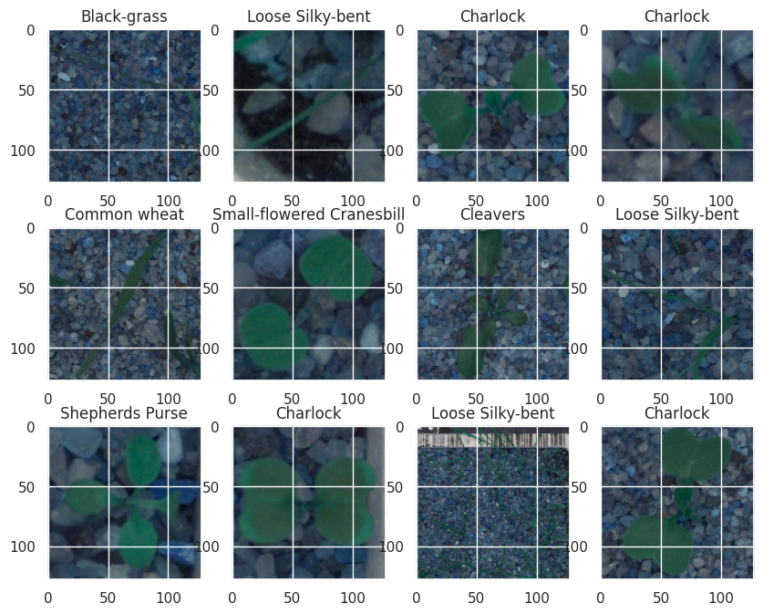

```python
# Call the plot_random_images() to plot the images
plot_random_images(images,labels)
```

*Observation*

- Images of each class are properly loaded and appear distinct.

# **Data Pre-Processing**

**Checking the image format**

```python
# Determine the color of the images whether they are RGB or GBR

# Extracts the number of channels from the first image
height, width, channels = images[0].shape

# Extract the first image
image = images[0]

# Check the format of the image
if channels == 3 and image[0, 0, 0] == image[0, 0, 2]:
    print("Image is in RGB format.")
elif channels == 3 and image[0, 0, 0] == image[0, 0, 0]:
    print("Image is in BGR format.")
else:
    print("Image format is not RGB or BGR.")
```

```
Image is in BGR format.
```

*Observation*

- The images are in BGR format. We will convert to RGB format.

### Converting the BGR images to RGB images.

```python
# Converting the images from BGR to RGB using cvtColor function of OpenCV
RGB_images = images
for i in range(len(images)):
  RGB_images[i] = cv2.cvtColor(images[i], cv2.COLOR_BGR2RGB)
```

*Observation*

- The images have been converted to RGB format.

### Data Splitting for Modeling

- As we don't have enough images in our dataset, we will only use 10% of our data for testing, 10% of our data for validation and 80% of our data for training.
- We are using the train_test_split() function from scikit-learn. Here, we split the dataset into three parts, train,test and validation.

```python
# Split data into train, test & validation
X_temp, X_test, y_temp, y_test = train_test_split(np.array(RGB_images),labels , test_size=0.1, random_state=1,stratify=labels)
X_train, X_val, y_train, y_val = train_test_split(X_temp,y_temp , test_size=0.1, random_state=1,stratify=y_temp)
```

```python
# Check the shape of train, test and validation data
print(f"The shape of X_train is {X_train.shape} and y_train is {y_train.shape}")
print(f"The shape of X_val is {X_val.shape} and y_val {y_val.shape}")
print(f"The shape of X_test is {X_test.shape} and y_test {y_test.shape}")
```

```
The shape of X_train is (3847, 128, 128, 3) and y_train is (3847, 1)
The shape of X_val is (428, 128, 128, 3) and y_val (428, 1)
The shape of X_test is (475, 128, 128, 3) and y_test (475, 1)
```

### Class Weight to Cater for the imbalanced data

As we say in the EDA, the classes are imbalanced. Using 'balanced' as our strategy chosen for computing class weights will adjusts the weights inversely proportional to class frequencies.

```python
class_weights = class_weight.compute_class_weight(class_weight = "balanced",
                                                  classes = np.array(class_list),
                                                  y = y_train.values.reshape(-1)
                                                  )
class_weights = dict(zip(np.array(range(len(class_list))), class_weights))
#print calculated class weights
class_weights
```

```
{0: 1.5050860719874803,
 1: 1.0145042194092826,
 2: 1.3818247126436782,
 3: 0.6476430976430977,
 4: 1.7909683426443204,
 5: 0.8348524305555556,
 6: 0.604874213836478,
 7: 1.7909683426443204,
 8: 0.7669457735247209,
 9: 1.714349376114082,
 10: 0.7974709784411277,
 11: 1.0275106837606838}
```

**Observation**

- The class_weights array contains the computed class weights that we will use for handling class imbalance during model training.

### Encoding the target labels

We will use the LabelBinarizer, a class from scikit-learn's preprocessing module, to convert categorical labels into binary format.

```python
# Convert labels from names to one hot vectors using LabelBinarizer

enc = LabelBinarizer()

# Fit & transform on train set
y_train_encoded = enc.fit_transform(y_train)

# Transform on test & val set
y_val_encoded=enc.transform(y_val)
y_test_encoded=enc.transform(y_test)
```

```python
print(f"Encoded y_train shape: {y_train_encoded.shape}")
print(f"Encoded y_val shape: {y_val_encoded.shape}")
print(f"Encoded y_test shape: {y_test_encoded.shape}")
```

```
Encoded y_train shape: (3847, 12)
Encoded y_val shape: (428, 12)
Encoded y_test shape: (475, 12)
```

**Observation**

- The variables y_train_encoded, y_val_encoded, and y_test_encoded contains the encoded binary representations of the class labels, which we will use for training and evaluating our multi-label classification models.

### Data Normalization

Our method of normalization here will be **scaling** - we shall **divide all the pixel values by 255 to standardize the images to have values between 0-1.**

```python
# Code to normalize the image pixels of train, test and validation data
X_train_normalized = X_train.astype('float32')/255.0
X_val_normalized = X_val.astype('float32')/255.0
X_test_normalized = X_test.astype('float32')/255.0
```

# **Model Building**

```python
# Clearing backend
backend.clear_session()
```

```python
# Fixing the seed for random number generators
np.random.seed(1)
random.seed(1)
tf.random.set_seed(1)
```

### **Model1**: Our first model is going to be without any kind of regularization.

```python
# Intializing a sequential model
model1 = Sequential()

# Adding first conv layer with 128 filters and kernel size 3x3 , padding 'same' provides the output size same as the input size
model1.add(Conv2D(128, (3, 3), activation='relu', padding="same", input_shape=(128, 128, 3)))

# Adding max pooling to reduce the size of output of first conv layer
model1.add(MaxPooling2D((2, 2), padding = 'same'))

# Adding two convolution (256 & 512) and max-pooling layers activation = relu
model1.add(Conv2D(256, (3, 3), activation='relu', padding="same"))
model1.add(MaxPooling2D((2, 2), padding = 'same'))

model1.add(Conv2D(512, (3, 3), activation='relu', padding="same"))
model1.add(MaxPooling2D((2, 2), padding = 'same'))

# flattening the output of the conv layer after max pooling to make it ready for creating dense connections
model1.add(Flatten())

# Adding 2 fully connected dense layers with 100 & 20 neurons with 30% dropour rate
model1.add(Dense(100, activation='relu'))


# Adding the output layer with 12 neurons and activation functions as softmax for a multi-class classification
model1.add(Dense(12, activation='softmax'))

# Use the Adam Optimizer
opt=Adam()

# Compile the model
model1.compile(optimizer=opt, loss='categorical_crossentropy', weighted_metrics=['accuracy'])

# Generate the summary of the model
model1.summary()
```

```
Model: "sequential"
_________________________________________________________________
 Layer (type)                Output Shape              Param #
=================================================================
 conv2d (Conv2D)             (None, 128, 128, 128)     3584

 max_pooling2d (MaxPooling2D  (None, 64, 64, 128)      0
 )

 conv2d_1 (Conv2D)           (None, 64, 64, 256)       295168

 max_pooling2d_1 (MaxPooling  (None, 32, 32, 256)      0
 2D)

 conv2d_2 (Conv2D)           (None, 32, 32, 512)       1180160

 max_pooling2d_2 (MaxPooling  (None, 16, 16, 512)      0
 2D)

 flatten (Flatten)           (None, 131072)            0

 dense (Dense)               (None, 100)               13107300

 dense_1 (Dense)             (None, 12)                1212

=================================================================
Total params: 14,587,424
Trainable params: 14,587,424
Non-trainable params: 0
_________________________________________________________________
```

**Observation**

- Our model1 has 3 Convolutional layers, 3 Pooling layers, 1 Fully connected (dense) layer and the Output layer.
- There are 14,587,424 Trainable parameters, 0 Non-trainable parameters given 14,587,424 Total parameters.
- No dropouts, no normalizations.

**Fitting the model on the train data**

```python
# Fit the model on train and using the validation data for validation
history1 = model1.fit(
            X_train_normalized, y_train_encoded,
            epochs=50,
            validation_data=(X_val_normalized,y_val_encoded),
            batch_size=32,
            class_weight=class_weights,
            verbose=2
)
```

```
121/121 - 8s - loss: 2.4954 - accuracy: 0.0882 - val_loss: 2.4891 - val_accuracy: 0.1098 - 8s/epoch - 68ms/step
121/121 - 2s - loss: 2.0777 - accuracy: 0.2547 - val_loss: 1.8504 - val_accuracy: 0.3061 - 2s/epoch - 14ms/step
121/121 - 2s - loss: 1.5072 - accuracy: 0.4516 - val_loss: 1.5981 - val_accuracy: 0.3879 - 2s/epoch - 14ms/step
121/121 - 2s - loss: 1.2327 - accuracy: 0.5436 - val_loss: 1.1899 - val_accuracy: 0.5584 - 2s/epoch - 14ms/step
121/121 - 2s - loss: 0.9786 - accuracy: 0.6428 - val_loss: 1.0414 - val_accuracy: 0.6425 - 2s/epoch - 14ms/step
121/121 - 2s - loss: 0.7810 - accuracy: 0.7154 - val_loss: 1.2420 - val_accuracy: 0.5981 - 2s/epoch - 14ms/step
121/121 - 2s - loss: 0.6709 - accuracy: 0.7604 - val_loss: 0.9540 - val_accuracy: 0.7126 - 2s/epoch - 14ms/step
121/121 - 2s - loss: 0.5493 - accuracy: 0.8030 - val_loss: 0.9149 - val_accuracy: 0.7407 - 2s/epoch - 14ms/step
121/121 - 2s - loss: 0.4528 - accuracy: 0.8417 - val_loss: 1.1661 - val_accuracy: 0.6659 - 2s/epoch - 14ms/step
121/121 - 2s - loss: 0.4349 - accuracy: 0.8447 - val_loss: 0.9937 - val_accuracy: 0.7266 - 2s/epoch - 14ms/step
121/121 - 2s - loss: 0.3143 - accuracy: 0.8864 - val_loss: 1.0309 - val_accuracy: 0.7453 - 2s/epoch - 14ms/step
121/121 - 2s - loss: 0.2944 - accuracy: 0.8978 - val_loss: 1.0091 - val_accuracy: 0.7126 - 2s/epoch - 14ms/step
121/121 - 2s - loss: 0.2616 - accuracy: 0.9137 - val_loss: 1.0481 - val_accuracy: 0.7500 - 2s/epoch - 14ms/step
121/121 - 2s - loss: 0.1671 - accuracy: 0.9440 - val_loss: 1.3126 - val_accuracy: 0.6986 - 2s/epoch - 14ms/step
121/121 - 2s - loss: 0.1583 - accuracy: 0.9473 - val_loss: 1.3876 - val_accuracy: 0.7033 - 2s/epoch - 14ms/step
121/121 - 2s - loss: 0.2221 - accuracy: 0.9276 - val_loss: 1.5469 - val_accuracy: 0.6636 - 2s/epoch - 14ms/step
121/121 - 2s - loss: 0.1434 - accuracy: 0.9569 - val_loss: 1.3697 - val_accuracy: 0.7336 - 2s/epoch - 14ms/step
121/121 - 2s - loss: 0.0735 - accuracy: 0.9791 - val_loss: 1.5678 - val_accuracy: 0.7220 - 2s/epoch - 14ms/step
121/121 - 2s - loss: 0.0672 - accuracy: 0.9796 - val_loss: 1.8458 - val_accuracy: 0.7243 - 2s/epoch - 14ms/step
121/121 - 2s - loss: 0.1267 - accuracy: 0.9614 - val_loss: 1.5053 - val_accuracy: 0.7336 - 2s/epoch - 14ms/step
121/121 - 2s - loss: 0.1146 - accuracy: 0.9668 - val_loss: 1.3649 - val_accuracy: 0.7430 - 2s/epoch - 14ms/step
121/121 - 2s - loss: 0.0385 - accuracy: 0.9907 - val_loss: 1.5100 - val_accuracy: 0.7430 - 2s/epoch - 14ms/step
121/121 - 2s - loss: 0.0175 - accuracy: 0.9966 - val_loss: 1.5484 - val_accuracy: 0.7430 - 2s/epoch - 14ms/step
121/121 - 2s - loss: 0.0112 - accuracy: 0.9992 - val_loss: 1.6742 - val_accuracy: 0.7360 - 2s/epoch - 14ms/step
121/121 - 2s - loss: 0.0089 - accuracy: 0.9992 - val_loss: 1.8640 - val_accuracy: 0.7103 - 2s/epoch - 14ms/step
121/121 - 2s - loss: 0.0616 - accuracy: 0.9793 - val_loss: 2.1453 - val_accuracy: 0.6846 - 2s/epoch - 14ms/step
121/121 - 2s - loss: 0.1179 - accuracy: 0.9674 - val_loss: 1.6217 - val_accuracy: 0.7266 - 2s/epoch - 14ms/step
121/121 - 2s - loss: 0.0203 - accuracy: 0.9975 - val_loss: 1.8092 - val_accuracy: 0.7407 - 2s/epoch - 14ms/step
121/121 - 2s - loss: 0.0072 - accuracy: 0.9994 - val_loss: 1.8492 - val_accuracy: 0.7477 - 2s/epoch - 14ms/step
121/121 - 2s - loss: 0.0035 - accuracy: 0.9998 - val_loss: 1.8926 - val_accuracy: 0.7477 - 2s/epoch - 14ms/step
121/121 - 2s - loss: 0.0022 - accuracy: 0.9998 - val_loss: 1.9303 - val_accuracy: 0.7407 - 2s/epoch - 14ms/step
121/121 - 2s - loss: 0.0016 - accuracy: 0.9998 - val_loss: 1.9906 - val_accuracy: 0.7360 - 2s/epoch - 14ms/step
121/121 - 2s - loss: 0.0013 - accuracy: 0.9998 - val_loss: 2.0413 - val_accuracy: 0.7407 - 2s/epoch - 14ms/step
121/121 - 2s - loss: 0.0010 - accuracy: 0.9998 - val_loss: 2.0818 - val_accuracy: 0.7336 - 2s/epoch - 14ms/step
121/121 - 2s - loss: 8.4297e-04 - accuracy: 1.0000 - val_loss: 2.1227 - val_accuracy: 0.7360 - 2s/epoch - 14ms/step
121/121 - 2s - loss: 7.2592e-04 - accuracy: 1.0000 - val_loss: 2.1693 - val_accuracy: 0.7383 - 2s/epoch - 14ms/step
121/121 - 2s - loss: 7.0925e-04 - accuracy: 1.0000 - val_loss: 2.2351 - val_accuracy: 0.7360 - 2s/epoch - 14ms/step
121/121 - 2s - loss: 0.2557 - accuracy: 0.9288 - val_loss: 1.5677 - val_accuracy: 0.7313 - 2s/epoch - 14ms/step
121/121 - 2s - loss: 0.0670 - accuracy: 0.9806 - val_loss: 1.6343 - val_accuracy: 0.7150 - 2s/epoch - 14ms/step
121/121 - 2s - loss: 0.0390 - accuracy: 0.9893 - val_loss: 1.6090 - val_accuracy: 0.7383 - 2s/epoch - 14ms/step
121/121 - 2s - loss: 0.0116 - accuracy: 0.9978 - val_loss: 1.6540 - val_accuracy: 0.7640 - 2s/epoch - 14ms/step
121/121 - 2s - loss: 0.0047 - accuracy: 0.9995 - val_loss: 1.7524 - val_accuracy: 0.7407 - 2s/epoch - 14ms/step
121/121 - 2s - loss: 0.0014 - accuracy: 1.0000 - val_loss: 1.8207 - val_accuracy: 0.7453 - 2s/epoch - 14ms/step
121/121 - 2s - loss: 0.0010 - accuracy: 1.0000 - val_loss: 1.8785 - val_accuracy: 0.7453 - 2s/epoch - 14ms/step
121/121 - 2s - loss: 8.1096e-04 - accuracy: 1.0000 - val_loss: 1.9218 - val_accuracy: 0.7407 - 2s/epoch - 14ms/step
121/121 - 2s - loss: 7.3181e-04 - accuracy: 1.0000 - val_loss: 1.9654 - val_accuracy: 0.7407 - 2s/epoch - 14ms/step
121/121 - 2s - loss: 5.9612e-04 - accuracy: 1.0000 - val_loss: 1.9993 - val_accuracy: 0.7407 - 2s/epoch - 14ms/step
121/121 - 2s - loss: 5.1800e-04 - accuracy: 1.0000 - val_loss: 2.0232 - val_accuracy: 0.7383 - 2s/epoch - 14ms/step
121/121 - 2s - loss: 4.5465e-04 - accuracy: 1.0000 - val_loss: 2.0639 - val_accuracy: 0.7383 - 2s/epoch - 14ms/step
121/121 - 2s - loss: 3.9495e-04 - accuracy: 1.0000 - val_loss: 2.0902 - val_accuracy: 0.7360 - 2s/epoch - 14ms/step
```

**Train Accuracy for model1**

```python
# Train Accuracy for model1
train_accuracy1 = model1.evaluate(X_train_normalized, y_train_encoded, verbose=2)
```

```
121/121 - 1s - loss: 3.9255e-04 - accuracy: 1.0000 - 782ms/epoch - 6ms/step
```

**Model Evaluation**

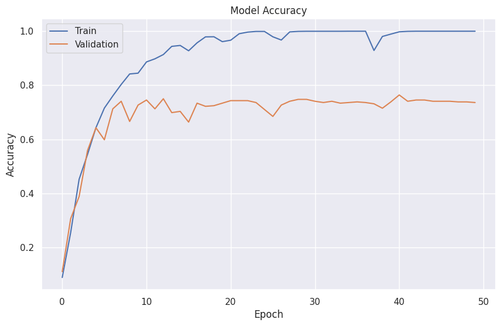

```python
# Plot the Accuracy/Epoch graph for train and val

plt.plot(history1.history['accuracy'])
plt.plot(history1.history['val_accuracy'])
plt.title('Model Accuracy')
plt.ylabel('Accuracy')
plt.xlabel('Epoch')
plt.legend(['Train', 'Validation'], loc='upper left')
plt.show()
```

**Observation**

- `model1` is overfitting and not generalizing well on the validation set (with 100% accuracy on the train set and about 74% accuracy on the validation set). This is expected.

**Evaluate the model on test data**

```python
# Evaluating model on Test data
test_accuracy1 = model1.evaluate(X_test_normalized, y_test_encoded, verbose=2)
```

```
15/15 - 0s - loss: 2.2506 - accuracy: 0.7600 - 283ms/epoch - 19ms/step
```

**Observation**

**Plotting the Confusion Matrix**

```python
# Get the output as probablities for each category
y_pred1=model1.predict(X_test_normalized)
```

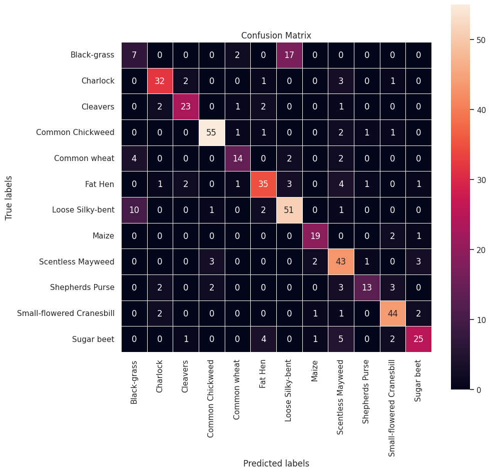

```python
# Confusion Matrix

# Obtaining the categorical values from y_test_encoded and y_pred
y_pred_arg1=np.argmax(y_pred1,axis=1)
y_test_arg=np.argmax(y_test_encoded,axis=1)

# Plotting the Confusion Matrix using confusion matrix() function which is also predefined tensorflow module
confusion_matrix = tf.math.confusion_matrix(y_test_arg,y_pred_arg1)

f, ax = plt.subplots(figsize=(10, 10))
sns.heatmap(
    confusion_matrix,
    annot=True,
    linewidths=.4,
    fmt="d",
    square=True,
    ax=ax
)
# Setting the labels to both the axes
ax.set_xlabel('Predicted labels');ax.set_ylabel('True labels');
ax.set_title('Confusion Matrix');
ax.xaxis.set_ticklabels(list(enc.classes_),rotation=90)
ax.yaxis.set_ticklabels(list(enc.classes_),rotation=0)
plt.show()
```

**Observation**

**Plotting Classification Report**

```python
# Generate the classification report
report = classification_report(y_test_arg,y_pred_arg1)

# Print the classification report
print(report)
```

```
              precision    recall  f1-score   support

           0       0.33      0.27      0.30        26
           1       0.82      0.82      0.82        39
           2       0.82      0.79      0.81        29
           3       0.90      0.90      0.90        61
           4       0.74      0.64      0.68        22
           5       0.78      0.73      0.75        48
           6       0.70      0.78      0.74        65
           7       0.83      0.86      0.84        22
           8       0.66      0.83      0.74        52
           9       0.81      0.57      0.67        23
          10       0.83      0.88      0.85        50
          11       0.78      0.66      0.71        38

    accuracy                           0.76       475
   macro avg       0.75      0.73      0.73       475
weighted avg       0.76      0.76      0.76       475
```

**Observation**

- We see the details of the precision, recall and f1-score for each class.
- Again we see model1 has an accuracy of 76% on unseen data.

## **Model Performance Improvement**

**Reducing the Learning Rate:**

**ReduceLRonPlateau()** is a function that will be used to decrease the learning rate by some factor, if the loss is not decreasing for some time. This may start decreasing the loss at a smaller learning rate. There is a possibility that the loss may still not decrease. This may lead to executing the learning rate reduction again in an attempt to achieve a lower loss.

```python
# Code to monitor val_accuracy
learning_rate_reduction = ReduceLROnPlateau(monitor='val_accuracy',
                                            patience=3,
                                            verbose=1,
                                            factor=0.5,
                                            min_lr=0.00001)
```

### **Data Augmentation**

```python
# Clearing backend
from tensorflow.keras import backend
backend.clear_session()

# Fixing the seed for random number generators
import random
np.random.seed(1)
random.seed(1)
tf.random.set_seed(1)
```

```python
# Initialize the Data Augmentation function
train_datagen = ImageDataGenerator(
        rotation_range=90,        # randomly rotate images in the range
        fill_mode='nearest',      # use nearest neighbor as fill mode
        horizontal_flip=True,     # randomly flip images horizontally
        vertical_flip=True        # randomly flip images vertically
    )
```

### **model2**: The difference between our second model and the first is Data Augmentation and reducing the learning rate...this decreases the learning rate by some factor, if the loss is not decreasing for some time.

```python
# Intializing a sequential model
model2 = Sequential()

# Adding first conv layer with 128 filters and kernel size 3x3 , padding 'same' provides the output size same as the input size
model2.add(Conv2D(128, (3, 3), activation='relu', padding="same", input_shape=(128, 128, 3)))

# Adding max pooling to reduce the size of output of first conv layer
model2.add(MaxPooling2D((2, 2), padding = 'same'))

# Adding two convolution (256 & 512) and max-pooling layers activation = relu
model2.add(Conv2D(256, (3, 3), activation='relu', padding="same"))
model2.add(MaxPooling2D((2, 2), padding = 'same'))

model2.add(Conv2D(512, (3, 3), activation='relu', padding="same"))
model2.add(MaxPooling2D((2, 2), padding = 'same'))

# flattening the output of the conv layer after max pooling to make it ready for creating dense connections
model2.add(Flatten())

# Adding 2 fully connected dense layers with 100 & 20 neurons with 30% dropour rate
model2.add(Dense(100, activation='relu'))

# Adding the output layer with 12 neurons and activation functions as softmax for a multi-class classification
model2.add(Dense(12, activation='softmax'))

# Use the Adam Optimizer
opt=Adam()

# Compile the model
model2.compile(optimizer=opt, loss='categorical_crossentropy', weighted_metrics=['accuracy'])

# Generate the summary of the model
model2.summary()
```

```
Model: "sequential"
_________________________________________________________________
 Layer (type)                Output Shape              Param #
=================================================================
 conv2d (Conv2D)             (None, 128, 128, 128)     3584

 max_pooling2d (MaxPooling2D  (None, 64, 64, 128)      0
 )

 conv2d_1 (Conv2D)           (None, 64, 64, 256)       295168

 max_pooling2d_1 (MaxPooling  (None, 32, 32, 256)      0
 2D)

 conv2d_2 (Conv2D)           (None, 32, 32, 512)       1180160

 max_pooling2d_2 (MaxPooling  (None, 16, 16, 512)      0
 2D)

 flatten (Flatten)           (None, 131072)            0

 dense (Dense)               (None, 100)               13107300

 dense_1 (Dense)             (None, 12)                1212

=================================================================
Total params: 14,587,424
Trainable params: 14,587,424
Non-trainable params: 0
_________________________________________________________________
```

**Observation**

- Our model2 has 3 Convolutional layers, 3 Pooling layers, 1 Fully connected (dense) layer and the Output layer.
- There are 14,587,424 Trainable parameters, 0 Non-trainable parameters given 14,587,424 Total parameters.
- No dropouts, no normalizations.

**Fitting the model on the train data**

```python
# Epochs
epochs = 50
# Batch size
batch_size = 32

# Fit the model on Augmented train and using the validation data for validation
history2 = model2.fit(
            train_datagen.flow
                (X_train_normalized,y_train_encoded,
                 batch_size=batch_size, shuffle=False),
            epochs=epochs,
            validation_data=(X_val_normalized,y_val_encoded),
            steps_per_epoch=X_train_normalized.shape[0] // batch_size,
            class_weight=class_weights,
            callbacks=[learning_rate_reduction],
            verbose=2
)
```

```
120/120 - 14s - loss: 2.5247 - accuracy: 0.0828 - val_loss: 2.4855 - val_accuracy: 0.0491 - lr: 0.0010 - 14s/epoch - 119ms/step
120/120 - 13s - loss: 2.4833 - accuracy: 0.0761 - val_loss: 2.4852 - val_accuracy: 0.0491 - lr: 0.0010 - 13s/epoch - 106ms/step
120/120 - 13s - loss: 2.4855 - accuracy: 0.0762 - val_loss: 2.4856 - val_accuracy: 0.0491 - lr: 0.0010 - 13s/epoch - 106ms/step
120/120 - 13s - loss: 2.4848 - accuracy: 0.0782 - val_loss: 2.4852 - val_accuracy: 0.1005 - lr: 0.0010 - 13s/epoch - 105ms/step
120/120 - 13s - loss: 2.4845 - accuracy: 0.0822 - val_loss: 2.4853 - val_accuracy: 0.0491 - lr: 0.0010 - 13s/epoch - 107ms/step
120/120 - 13s - loss: 2.4867 - accuracy: 0.0835 - val_loss: 2.4855 - val_accuracy: 0.0491 - lr: 0.0010 - 13s/epoch - 105ms/step

Epoch 7: ReduceLROnPlateau reducing learning rate to 0.0005000000237487257.
120/120 - 13s - loss: 2.4857 - accuracy: 0.0800 - val_loss: 2.4857 - val_accuracy: 0.1005 - lr: 0.0010 - 13s/epoch - 107ms/step
120/120 - 13s - loss: 2.4848 - accuracy: 0.0768 - val_loss: 2.4857 - val_accuracy: 0.1005 - lr: 5.0000e-04 - 13s/epoch - 106ms/step
120/120 - 13s - loss: 2.4846 - accuracy: 0.0834 - val_loss: 2.4855 - val_accuracy: 0.1005 - lr: 5.0000e-04 - 13s/epoch - 105ms/step

Epoch 10: ReduceLROnPlateau reducing learning rate to 0.0002500000118743628.
120/120 - 13s - loss: 2.4826 - accuracy: 0.0820 - val_loss: 2.4855 - val_accuracy: 0.1005 - lr: 5.0000e-04 - 13s/epoch - 105ms/step
120/120 - 13s - loss: 2.4859 - accuracy: 0.0816 - val_loss: 2.4855 - val_accuracy: 0.1005 - lr: 2.5000e-04 - 13s/epoch - 106ms/step
120/120 - 13s - loss: 2.4844 - accuracy: 0.0779 - val_loss: 2.4855 - val_accuracy: 0.1005 - lr: 2.5000e-04 - 13s/epoch - 106ms/step

Epoch 13: ReduceLROnPlateau reducing learning rate to 0.0001250000059371814.
120/120 - 13s - loss: 2.4854 - accuracy: 0.0838 - val_loss: 2.4856 - val_accuracy: 0.1005 - lr: 2.5000e-04 - 13s/epoch - 105ms/step
120/120 - 13s - loss: 2.4864 - accuracy: 0.0833 - val_loss: 2.4856 - val_accuracy: 0.1005 - lr: 1.2500e-04 - 13s/epoch - 106ms/step
120/120 - 13s - loss: 2.4825 - accuracy: 0.0841 - val_loss: 2.4856 - val_accuracy: 0.1005 - lr: 1.2500e-04 - 13s/epoch - 105ms/step

Epoch 16: ReduceLROnPlateau reducing learning rate to 6.25000029685907e-05.
120/120 - 13s - loss: 2.4811 - accuracy: 0.0804 - val_loss: 2.4855 - val_accuracy: 0.1005 - lr: 1.2500e-04 - 13s/epoch - 105ms/step
120/120 - 13s - loss: 2.4864 - accuracy: 0.0833 - val_loss: 2.4855 - val_accuracy: 0.1005 - lr: 6.2500e-05 - 13s/epoch - 104ms/step
120/120 - 13s - loss: 2.4855 - accuracy: 0.0831 - val_loss: 2.4855 - val_accuracy: 0.1005 - lr: 6.2500e-05 - 13s/epoch - 106ms/step

Epoch 19: ReduceLROnPlateau reducing learning rate to 3.125000148429535e-05.
120/120 - 13s - loss: 2.4847 - accuracy: 0.0829 - val_loss: 2.4855 - val_accuracy: 0.1005 - lr: 6.2500e-05 - 13s/epoch - 106ms/step
120/120 - 13s - loss: 2.4848 - accuracy: 0.0836 - val_loss: 2.4855 - val_accuracy: 0.1005 - lr: 3.1250e-05 - 13s/epoch - 106ms/step
120/120 - 13s - loss: 2.4848 - accuracy: 0.0832 - val_loss: 2.4855 - val_accuracy: 0.1005 - lr: 3.1250e-05 - 13s/epoch - 106ms/step

Epoch 22: ReduceLROnPlateau reducing learning rate to 1.5625000742147677e-05.
120/120 - 13s - loss: 2.4863 - accuracy: 0.0831 - val_loss: 2.4855 - val_accuracy: 0.1005 - lr: 3.1250e-05 - 13s/epoch - 105ms/step
120/120 - 13s - loss: 2.4860 - accuracy: 0.0829 - val_loss: 2.4855 - val_accuracy: 0.1005 - lr: 1.5625e-05 - 13s/epoch - 106ms/step
120/120 - 13s - loss: 2.4861 - accuracy: 0.0825 - val_loss: 2.4855 - val_accuracy: 0.1005 - lr: 1.5625e-05 - 13s/epoch - 105ms/step

Epoch 25: ReduceLROnPlateau reducing learning rate to 1e-05.
120/120 - 13s - loss: 2.4850 - accuracy: 0.0829 - val_loss: 2.4855 - val_accuracy: 0.1005 - lr: 1.5625e-05 - 13s/epoch - 104ms/step
120/120 - 13s - loss: 2.4839 - accuracy: 0.0830 - val_loss: 2.4855 - val_accuracy: 0.1005 - lr: 1.0000e-05 - 13s/epoch - 106ms/step
```

[output cut: 9 more lines]

```
120/120 - 13s - loss: 2.4864 - accuracy: 0.0827 - val_loss: 2.4855 - val_accuracy: 0.1005 - lr: 1.0000e-05 - 13s/epoch - 107ms/step
120/120 - 13s - loss: 2.4836 - accuracy: 0.0839 - val_loss: 2.4855 - val_accuracy: 0.1005 - lr: 1.0000e-05 - 13s/epoch - 106ms/step
120/120 - 13s - loss: 2.4857 - accuracy: 0.0829 - val_loss: 2.4855 - val_accuracy: 0.1005 - lr: 1.0000e-05 - 13s/epoch - 106ms/step
120/120 - 13s - loss: 2.4852 - accuracy: 0.0838 - val_loss: 2.4855 - val_accuracy: 0.1005 - lr: 1.0000e-05 - 13s/epoch - 107ms/step
120/120 - 13s - loss: 2.4830 - accuracy: 0.0839 - val_loss: 2.4855 - val_accuracy: 0.1005 - lr: 1.0000e-05 - 13s/epoch - 106ms/step
120/120 - 13s - loss: 2.4836 - accuracy: 0.0828 - val_loss: 2.4855 - val_accuracy: 0.1005 - lr: 1.0000e-05 - 13s/epoch - 106ms/step
120/120 - 13s - loss: 2.4838 - accuracy: 0.0832 - val_loss: 2.4855 - val_accuracy: 0.1005 - lr: 1.0000e-05 - 13s/epoch - 105ms/step
120/120 - 13s - loss: 2.4842 - accuracy: 0.0834 - val_loss: 2.4855 - val_accuracy: 0.1005 - lr: 1.0000e-05 - 13s/epoch - 106ms/step
120/120 - 13s - loss: 2.4887 - accuracy: 0.0835 - val_loss: 2.4855 - val_accuracy: 0.1005 - lr: 1.0000e-05 - 13s/epoch - 106ms/step
120/120 - 13s - loss: 2.4830 - accuracy: 0.0839 - val_loss: 2.4855 - val_accuracy: 0.1005 - lr: 1.0000e-05 - 13s/epoch - 108ms/step
120/120 - 13s - loss: 2.4839 - accuracy: 0.0830 - val_loss: 2.4855 - val_accuracy: 0.1005 - lr: 1.0000e-05 - 13s/epoch - 106ms/step
120/120 - 13s - loss: 2.4854 - accuracy: 0.0834 - val_loss: 2.4855 - val_accuracy: 0.1005 - lr: 1.0000e-05 - 13s/epoch - 106ms/step
120/120 - 13s - loss: 2.4858 - accuracy: 0.0838 - val_loss: 2.4855 - val_accuracy: 0.1005 - lr: 1.0000e-05 - 13s/epoch - 105ms/step
120/120 - 13s - loss: 2.4853 - accuracy: 0.0836 - val_loss: 2.4855 - val_accuracy: 0.1005 - lr: 1.0000e-05 - 13s/epoch - 105ms/step
120/120 - 13s - loss: 2.4844 - accuracy: 0.0832 - val_loss: 2.4855 - val_accuracy: 0.1005 - lr: 1.0000e-05 - 13s/epoch - 105ms/step
```

**Train Accuracy for model2**

```python
# Train Accuracy for model2
train_accuracy2 = model2.evaluate(X_train_normalized, y_train_encoded, verbose=2)
```

```
121/121 - 1s - loss: 2.4856 - accuracy: 0.0998 - 814ms/epoch - 7ms/step
```

**Model Evaluation**

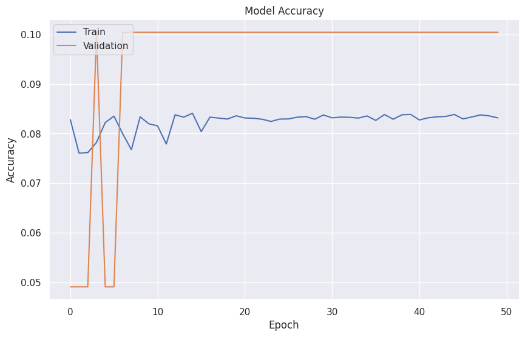

```python
plt.plot(history2.history['accuracy'])
plt.plot(history2.history['val_accuracy'])
plt.title('Model Accuracy')
plt.ylabel('Accuracy')
plt.xlabel('Epoch')
plt.legend(['Train', 'Validation'], loc='upper left')
plt.show()
```

**Observation**

- `model2` performed poorly and doesn't converge

**Evaluate the model on test data**

```python
# Evaluating model on Test data
test_accuracy2 = model2.evaluate(X_test_normalized, y_test_encoded, verbose=2)
```

```
15/15 - 0s - loss: 2.4855 - accuracy: 0.1011 - 124ms/epoch - 8ms/step
```

**Observation**

```python
# Get the output as probablities for each category
y_pred2=model2.predict(X_test_normalized)
```

**Plotting the Confusion Matrix**

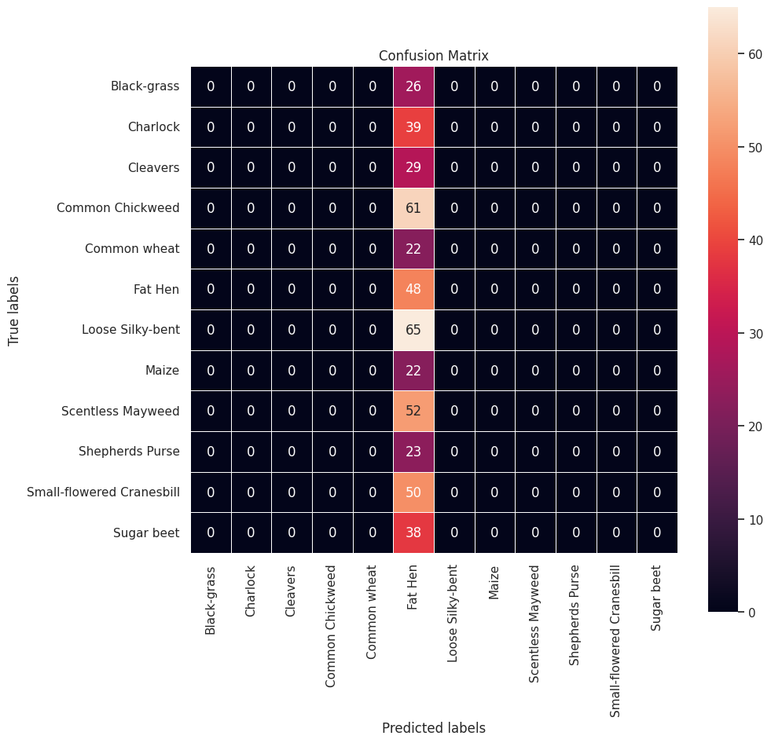

```python
# Confusion Matrix

# Obtaining the categorical values from y_test_encoded and y_pred
y_pred_arg2=np.argmax(y_pred2,axis=1)
y_test_arg=np.argmax(y_test_encoded,axis=1)

# Plotting the Confusion Matrix using confusion matrix() function which is also predefined tensorflow module
confusion_matrix = tf.math.confusion_matrix(y_test_arg,y_pred_arg2)

f, ax = plt.subplots(figsize=(10, 10))
sns.heatmap(
    confusion_matrix,
    annot=True,
    linewidths=.4,
    fmt="d",
    square=True,
    ax=ax
)
# Setting the labels to both the axes
ax.set_xlabel('Predicted labels');ax.set_ylabel('True labels');
ax.set_title('Confusion Matrix');
ax.xaxis.set_ticklabels(list(enc.classes_),rotation=90)
ax.yaxis.set_ticklabels(list(enc.classes_),rotation=0)
plt.show()
```

**Observation**

- model2 performed very poorly and did not converge.

**Plotting Classification Report**

```python
# Generate the classification report
report = classification_report(y_test_arg,y_pred_arg2)

# Print the classification report
print(report)
```

```
              precision    recall  f1-score   support

           0       0.00      0.00      0.00        26
           1       0.00      0.00      0.00        39
           2       0.00      0.00      0.00        29
           3       0.00      0.00      0.00        61
           4       0.00      0.00      0.00        22
           5       0.10      1.00      0.18        48
           6       0.00      0.00      0.00        65
           7       0.00      0.00      0.00        22
           8       0.00      0.00      0.00        52
           9       0.00      0.00      0.00        23
          10       0.00      0.00      0.00        50
          11       0.00      0.00      0.00        38

    accuracy                           0.10       475
   macro avg       0.01      0.08      0.02       475
weighted avg       0.01      0.10      0.02       475
```

**Observation**